Skip to contents

# Integrating corVis with other packages

Amit Chinwan and Catherine Hurley

2023-02-27

This vignette provides information on how data structures or display methods in *corVis* can be used with other R packages. We separate out the calculation and visualisation steps in *corVis*, which makes it an open ended package for both data structures and displays.

## Using data structures from corVis with other packages

| name | nn | ff | oo | nf | from | range |
| --- | --- | --- | --- | --- | --- | --- |
| tbl_cor | y |  |  |  | stats::cor | [-1,1] |
| tbl_dcor | y |  |  |  | energy::dcor2d | [0,1] |
| tbl_mine | y |  |  |  | minerva::mine | [0,1] |
| tbl_ace | y | y |  | y | corVis | [0,1] |
| tbl_cancor | y | y |  | y | corVis | [0,1] |
| tbl_nmi | y | y |  | y | linkspotter::maxNMI | [0,1] |
| tbl_polycor |  |  | y |  | polycor::polychor | [-1,1] |
| tbl_tau |  |  | y |  | DescTools::KendalTauA,B,C,W | [-1,1] |
| tbl_gkGamma |  |  | y |  | DescTools::GoodmanKruskalGamma | [-1,1] |
| tbl_gkTau |  |  | y |  | DescTools::GoodmanKruskalTau | [0,1] |
| tbl_uncertainty |  | y |  |  | DescTools::UncertCoef | [0,1] |
| tbl_chi |  | y |  |  | DescTools::ContCoef | [0,1] |

Table 1: Table of association measures available in the package corVis

An analyst can follow *Calculating associations using corVis* vignette for calculating association measures. These data structures are then used with other packages to display association measures.

### Visualising association measures using `corrplot`

The package provides an implementation of the methods in Friendly (2002) and produces correlation display in matrix layout. The correlation displays in the package are only applicable to numeric variables in a dataset. Figure 1 shows the correlation plot of the numeric variables in penguins data.

```r
library(corrplot)
df <- penguins
df_num <- df |>
  dplyr::select(where(is.numeric))

corrplot(cor(df_num,use = "pairwise.complete.obs"))
```

[figure not shown]

Figure 1: Correlation plot for penguins data using `corrplot`.

```r
penguins_assoc <- calc_assoc(df)

penguins_assoc_mat <- matrix_assoc(penguins_assoc)

corrplot(penguins_assoc_mat, diag = F)
```

[figure not shown]

Figure 2: Association plot for penguins data using association measures calculated by `corVis` and visulaized with `corrplot`.

### Visualising association measures using `linkspotter`

The `linkspotter` package calculates and visualizes association for numeric and factor variables using a network layout plot. The nodes show the variables and the edges represent the measure of association between pair of variables. The width of edge maps to absolute correlation among the nodes. Two nodes are connected if the `corMethod` is defined for the variable pairs.

```r
library(linkspotter)

corCouples<-multiBivariateCorrelation(df)
```

```
## Number of variables: 8
## Number of couples: 28
## Number of observations: 344
## Coef.: pearson, spearman, kendall, mic, MaxNMI
## Start time: 2023-02-27 10:36:21
## Correlation coef. computation finished: 2023-02-27 10:36:25
```

```r
linkspotterGraph(corDF = corCouples, corMethod = "pearson", smoothEdges = FALSE,
  dynamicNodes = FALSE)
```

[interactive chart not shown]

Figure 3: Association display for penguins data in a network layout.

```r
penguins_assoc <- calc_assoc(df)

corCouples<-multiBivariateCorrelation(df)
corCouples$pearson <- penguins_assoc$measure

linkspotterGraph(corDF = corCouples,corMethod = "pearson", smoothEdges = FALSE,
  dynamicNodes = FALSE)
```

[output not shown]

## Visualising association using `corrr`

Another package useful for exploring correlations is `corrr`. The main focus of the package is to create dataframes of correlation instead of matrices, which then can be explored by leveraging tools from *tidyverse*.

```r
library(corrr)
cor_df <- correlate(df_num)
glimpse(cor_df)
```

```
## Rows: 5
## Columns: 6
## $ term              <chr> "bill_length_mm", "bill_depth_mm", "flipper_length_m…
## $ bill_length_mm    <dbl> NA, -0.23505287, 0.65618134, 0.59510982, 0.05454458
## $ bill_depth_mm     <dbl> -0.23505287, NA, -0.58385122, -0.47191562, -0.060353…
## $ flipper_length_mm <dbl> 0.6561813, -0.5838512, NA, 0.8712018, 0.1696751
## $ body_mass_g       <dbl> 0.59510982, -0.47191562, 0.87120177, NA, 0.04220939
## $ year              <dbl> 0.05454458, -0.06035364, 0.16967511, 0.04220939, NA
```

```r
rplot(cor_df) +
  theme(axis.text = element_text(size = 7),
        axis.text.x = element_text(angle=30, hjust=1))
```

[figure not shown]

Figure 5: Association display for penguins data using `corrr`

Similar to `corrplot`, the packge `corrr` doesn’t support variables other than numeric. An analyst can calculate association measures for every variable pair using `corVis` and then display these measures using the visualizations offered by the `corrr`.

```r
penguins_assoc <- calc_assoc(df)
penguins_assoc_mat <- matrix_assoc(penguins_assoc)
penguins_assoc_df <- as.data.frame(penguins_assoc_mat)
rplot(penguins_assoc_df) +
  theme(axis.text = element_text(size = 7),
        axis.text.x = element_text(angle=30, hjust=1))
```

[figure not shown]

Figure 6: Association display for penguins data with association measures calculated using `corVis` and displayed using `corrr`

We can also display association measures using network layout with `corrr` for displaying the variables pairs having a higher value for association measures than a threshold. Figure 7 displays variable pairs in a network layout where measure value is greater than $0.4$.

```r
network_plot(penguins_assoc_df,min_cor = 0.4)
```

[figure not shown]

Figure 7: Association display in a network layout

## Visualising association using `corrgrapher`

Another package for displaying correlations in a network layout is `corrgrapher`. The network display is interactive and produced for every variable pair in a dataset, where the highly correlated variables (calculate comparable correlation coefficients for different types of variable pairs) are put closer to each other. Also, the edge width is proportional to the magnitude of the correlation value. The display also has an option to look at the distribution of a variable by clicking on the corresponding node/variable in the plot or selecting the variable from the drop down. Below is an example of the network plot.

[interactive chart not shown]

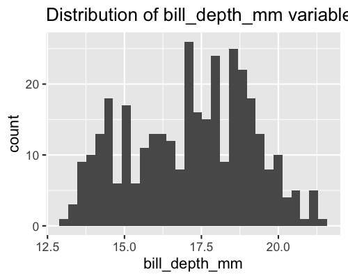

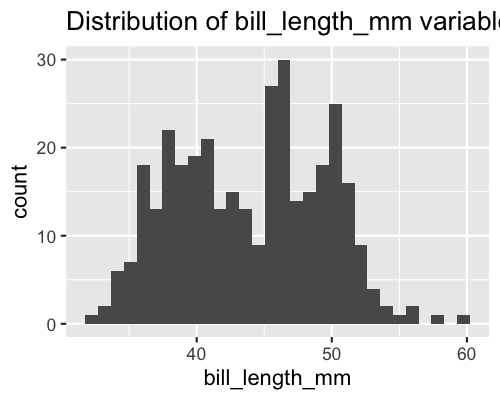

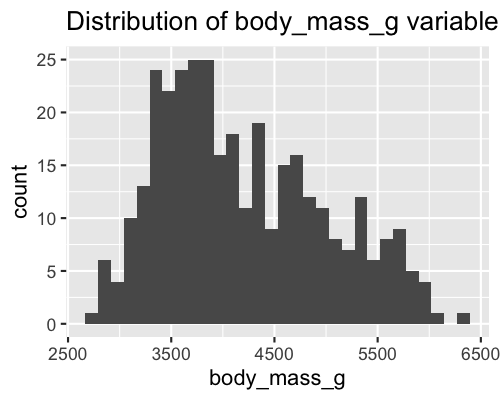

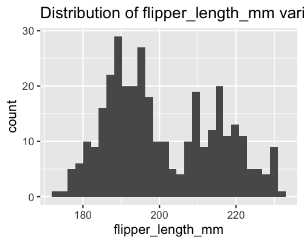

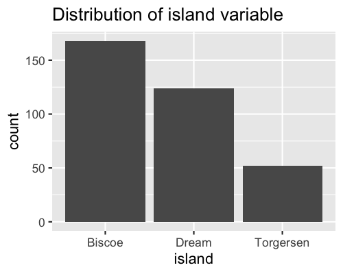

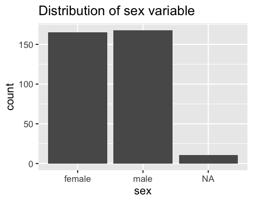

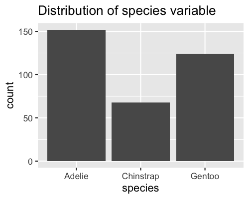

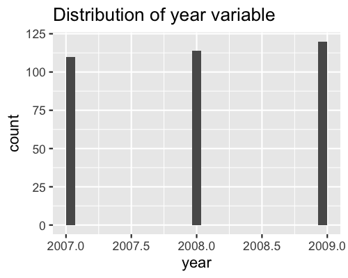

Figure 8: Correlation network using `corrgrapher`

Alternatively, we can use `corVis` for calculating pairwise association measures and display it using `corrgrapher`. In order to display a network layout, we will need to convert the tibble of calculated measures to a matrix. Figure 9 shows the network plot calculated association measures using `corVis`.

[interactive chart not shown]

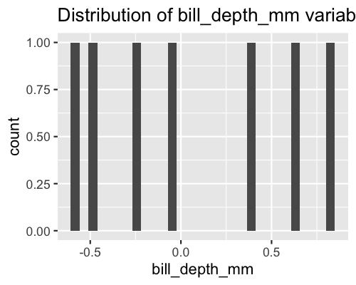

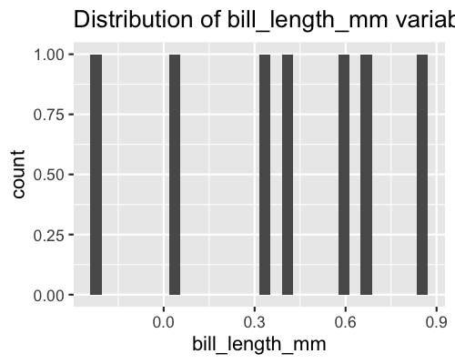

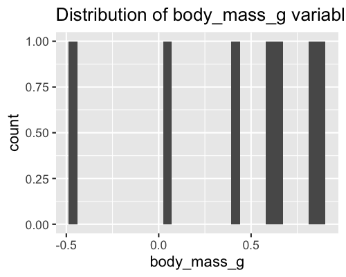

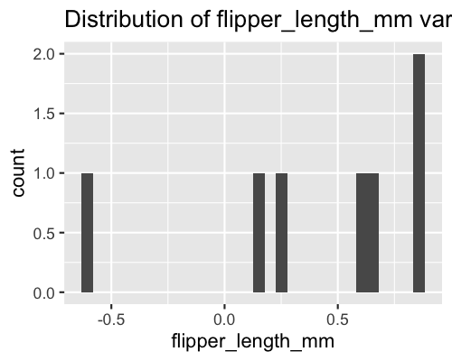

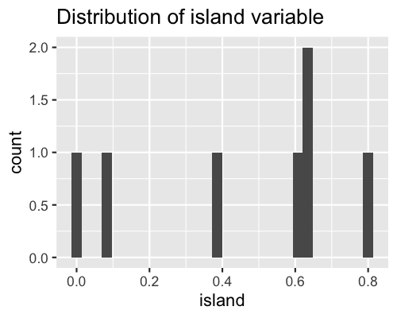

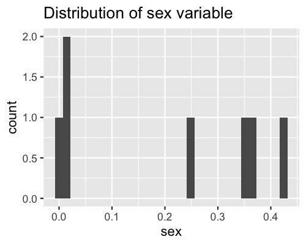

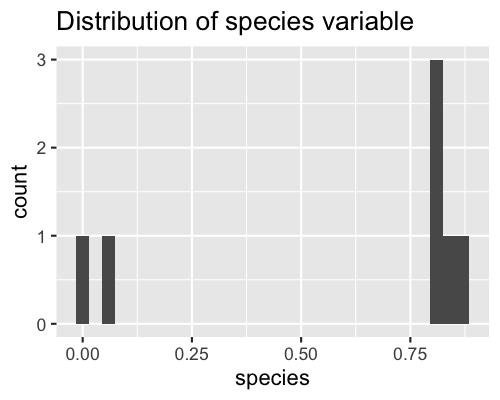

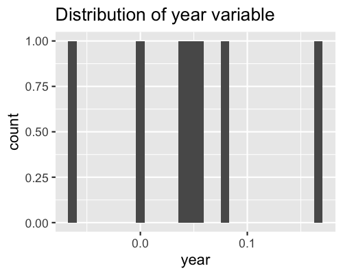

Figure 9: Association network plot for penguins data

The only limitation with this display is that the plot for individual variables lose its signficance when used with matrix input.